# Models Rmd

2026-06-26

# Models

- Package Installation

```r
library("rethinking")
library(dplyr)
library(dagitty)
```

## Causal effects of the DAG

```r
kdag<-dagitty("dag {
  S-> K <- T
  T -> S
  T -> SL -> K
}")
adjustmentSets(kdag, exposure="SL", outcome = "K")# This shows the backdoor path and how to stratify
```

```
## { T }
```

## Synthetic Data

- create a synthetic data with assumptions. See overview.pdf to check the data relationship.

```r
# Function of SL by Y
# This is arbitrary made by me, immitating the research by Susumu Tanabe and Rei Nakashima in 2026
# Y is between 0 and 1, which represents 16,000 years ago to 2,400 years ago.
myFunc <- function(x) {
case_when(
    0 <= x & x <= (-9+ 16)/(13.6)                          ~ -(x * (-13.6)) * 60 / 7 - 80,
    (-9.000+ 16)/(13.6) < x  & x <= (-7.500 + 16)/(13.6)   ~ -(x * (-13.6) + 7) * 46 / 3 - 20,
    (-7.500+ 16)/(13.6) < x   & x <= (-4.3+ 16)/(13.6)        ~ 3,
    (-4.3 + 16)/(13.6) < x   & x <= (-3.000+ 16)/(13.6)    ~ -(x * (-13.6) + 11.7) * (-60) / 13 + 3,
    (-3.000+ 16)/(13.6) < x   & x <= (-2.400+ 16)/(13.6)    ~ -(x * (-13.6) + 13) * 5 / 3 - 1,
    TRUE                                                    ~ 1
  )
}
curve(myFunc(x), col = 2, main = "Relative Sea Level and Year")

# Initialize Y
Y<- runif(200, 0, 1)

# T and SL caused by Y
T<- NULL
SL<-NULL
for (i in 1:length(Y)) {
    T[i]<-rpois(1,  Y[i]* 25)
    if(T[i] < 1) {T[i]<- 1}
    else if(T[i] > 25) {T[i]<- 25} # Make sure T is between 1 and 25
    SL[i]<- rnorm(1, myFunc(Y[i]), 5)
}

SL <- (SL - min(SL)) / (max(SL) - min(SL)) # to estimate easily, make it between 0 and 1

# Check the data
plot(T, SL, main = "Synthetic Data Plot(T and SL)")
plot(Y, T, main = "Synthetic Data Plot(Y and T)")
plot(Y, SL, main = "Synthetic Data Plot(Y and SL)")

# initialize dS with random numbers
dS<-rbeta(length(T), 1.2,1) * 200
# S is affected by Y and dS (omit T as T and S are correlated by Y)
S<-NULL
for(i in 1:length(T))S[i] <- rnorm(1, 5*Y[i] -dS[i]/50, 0.1)/25 + 0.3

# Check the data
range(S) # try to make less than 0.5
```

```
## [1] 0.1416801 0.4821805
```

```r
plot(density(S), main = "Density of Synthetic Data of S")

plot(dS, S, main = "Synthetic Data Plot(dS and S) \n with different groups")
legend(x = 0, y = 0.18, legend="red: T = 2 blue: T = 7 green: T = 13")
points(dS[T==2], S[T==2], col = 2, lwd =4)
points(dS[T==13], S[T==13], col = 3, lwd =4)
points(dS[T==7], S[T==7], col = 4, lwd =4)
plot(T, S, main = "Synthetic Data Plot(T and S)")
plot(Y, S, main = "Synthetic Data Plot(Y and S)")
plot(T, dS, main = "Synthetic Data Plot(T and dS)\n No correlation expected.") # no correlation
plot(SL, S, main = "Synthetic Data Plot(SL and S)\n auto-correlation")

# Initialize dK with random numbers
dK<-rbeta(length(T), 1.4,1)*400
# K is affected by SL, Y, S, dK
K<-NULL
for(i in 1:length(T))K[i] <- rnorm(1, 1 * SL[i] + 1 * Y[i] + 1 * S[i]- dK[i]/250, 0.2)/10 + 0.2

# Check the data
range(K)# try to make less than 0.5
```

```
## [1] 0.05281441 0.41890299
```

[figure not shown]

[figure not shown]

[figure not shown]

[figure not shown]

[figure not shown]

[figure not shown]

[figure not shown]

[figure not shown]

[figure not shown]

[figure not shown]

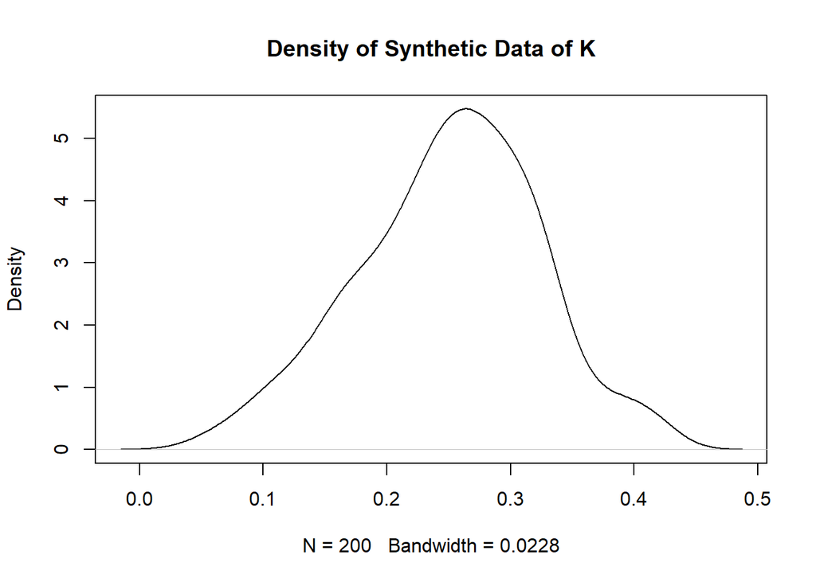

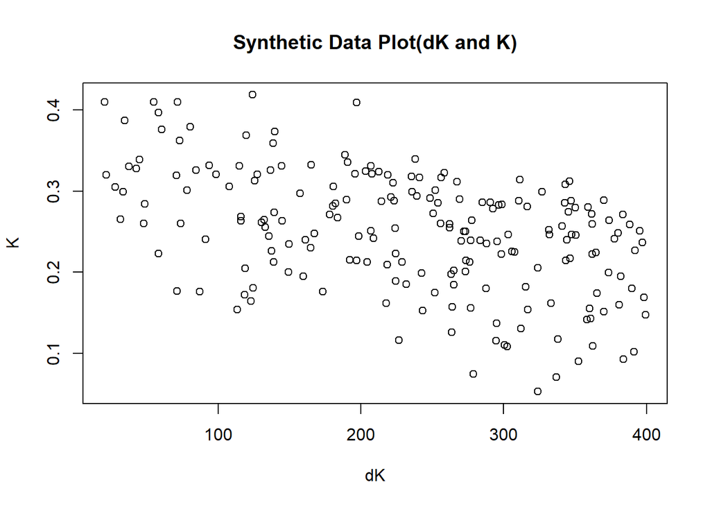

[13 more figures not shown]

```r
plot(density(K), main = "Density of Synthetic Data of K")
plot(dK, K, main = "Synthetic Data Plot(dK and K)")
plot(SL, K, main = "Synthetic Data Plot(SL and K)")
plot(Y, K, main = "Synthetic Data Plot(Y and K)")
plot(S, K, main = "Synthetic Data Plot(S and K)")
plot(dS, K, main = "Synthetic Data Plot(dS and K)\n No correlation expected.") # no correlation

# Standardize data without SL, S, K (those are ratio)
d<-list(T=T, dS=standardize(dS), S=S, K=K, dK=standardize(dK))

# check the data
plot(density(d$K), main = "Density of Synthetic Data of d$K")
plot(d$dK, d$K, main = "Synthetic Data Plot(d$dK and d$K)")
plot(SL, d$K, main = "Synthetic Data Plot(SL and d$K)")
plot(Y, d$K, main = "Synthetic Data Plot(Y and d$K)")
plot(d$T, d$K, main = "Synthetic Data Plot(d$T and d$K)")
plot(d$S, d$K, main = "Synthetic Data Plot(d$S and d$K)")
plot(d$dS, d$S, main = "Synthetic Data Plot(d$dS and d$S)")
plot(Y, d$S, main = "Synthetic Data Plot(Y and d$S)")
plot(d$dS, d$K, main = "Synthetic Data Plot(d$dS and d$K)\n No correlation expected.") # no correlation
```

## Prior Prediction

- Now I want to create a prior and statistical model.
- As in the overview, the Y and Sl are hidden parameter so how to initialize is important
- This time, to make it simple, I use logit function to immitate the $myFunction$

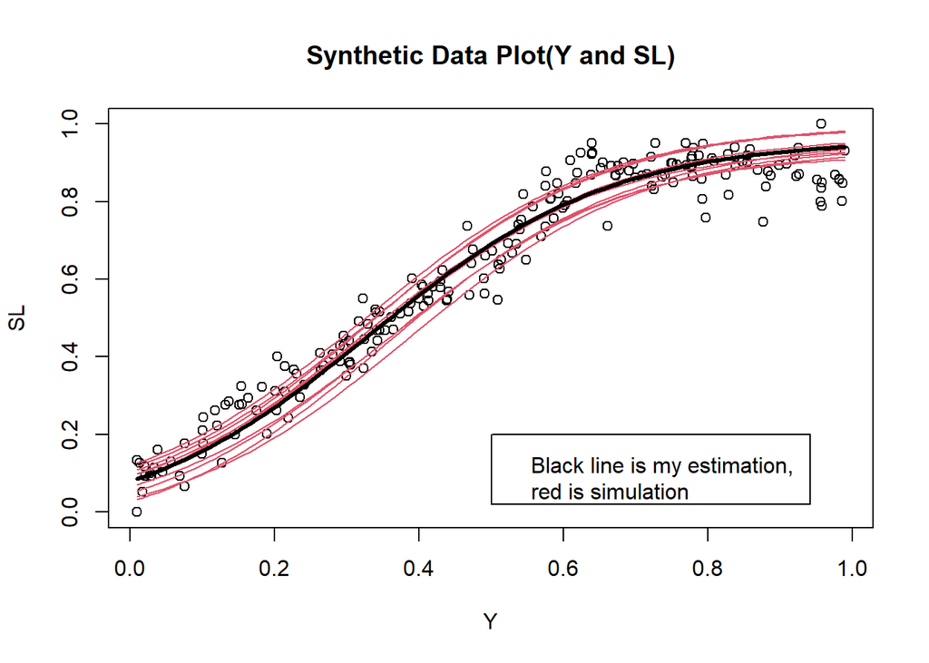

```r
plot(Y, SL, main = "Synthetic Data Plot(Y and SL)")
# Simulation
for(i in 1:10)curve(inv_logit(rnorm(1, 6, 0.2)*x + rnorm(1, -2, 0.2)) - rnorm(1, 0.04, 0.02), add =TRUE, col = 2)
curve(inv_logit(6*x - 2) - 0.04, add =TRUE, lwd = 3)
legend(0.5, 0.2,legend="Black line is my estimation, \nred is simulation")
```

## Model 1

- This is multi-model of the DAG with out any stratification See Overview pdf for details.
- There are a few messages to warning my priors. Since it only shows up during first iteration of warmup, we can safely ignore it.
- Warnings are annoying but relatively few so I just omit it for m1.2 and m1.3.

```r
m1<- ulam(
    alist (
    # Main model K
        K ~ normal(mu_K, U),
        logit(mu_K) <- aK + bK_S * S + bK_SL * SL[i] + bK_Y * Y[i] + bK_dK * dK + bK_T[T],
        # We do not know anything about this but think similar for all group.
        # Mean should start at 0 and has small variation
        # bK_T is regularized to maintain the efficiency.

        c(aK, bK_S,  bK_SL, bK_Y, bK_dK) ~ normal(0,0.1), # This is different from the other one, so that bK_T works well; otherwise, it does not somehow.
        vector[25]: bK_T <- bK_T_bar + sigma_bK_T * z_bK_T[T],
        bK_T_bar ~ normal(0, 0.1), # regularization but not high sigma
        sigma_bK_T ~ exponential(1), # Needs to be 1 to maintain bK_T.
        z_bK_T[T] ~ normal(0, 0.1),

        U ~ exponential(1),

    # Model S
        S ~ normal(mu_S, sigma_S),
        logit(mu_S) <- aS + bS_dS * dS + bS_Y * Y[i] + bS_T[T],

        # I am hoping/believing b_dS is negative, b_Y_S is positive, and bS_T is different for each one.
        c(aS, bS_Y, bS_dS) ~ normal(0,0.1),
        # bS_T is regularized.
        vector[25]: bS_T <- bS_T_bar + sigma_bS_T * z_bS_T[T],
        bS_T_bar ~ normal(0, 0.1),
        sigma_bS_T ~ exponential(1),
        z_bS_T[T] ~ normal(0, 0.1),

        sigma_S ~ exponential(1),

    # Model SL by Y
        # The log function and prior was refered to the previous research of Sea Level Change over time.
        # This function is abstruct so I will have to actually stan code to provide accurate estimates
        # ulam code in r does not allow us to hartd code the conditional function.
        # vector[200]: SL ~ normal(muSL + aSL2, sigmaSL),
        vector[200]: SL ~ normal(inv_logit(6 * Y - 2) - 0.04, 0.05),

    # Model T, This should be hard coded based on the previous research
        T ~ poisson(Y * 25),

    # Model T by Y
        vector[200]:Y ~ normal(0.5, 0.3)

    ), dat = d, constraints = list(
        SL    = "lower=0,upper=1", # SL is between 0 and 1
        Y    = "lower=0,upper=1" # Y is between 0 and 1
        #, T    = "lower=1,upper=25"  #this is unnecessary since T is provided in the dat
    ), chains=4, cores=4, iter= 4000, warmup = 2000, log_lik=TRUE, max_treedepth = 13, control = list(
    adapt_delta = 0.99
  )
)
```

[output not shown]

[output not shown]

[output not shown]

[output not shown]

```
## Running MCMC with 4 parallel chains, with 1 thread(s) per chain...
##
## Chain 1 Iteration:    1 / 4000 [  0%]  (Warmup)
```

```
## Chain 1 Informational Message: The current Metropolis proposal is about to be rejected because of the following issue:
```

```
## Chain 1 Exception: normal_lpdf: Scale parameter is 0, but must be positive! (in 'C:/Users/nobut/AppData/Local/Temp/RtmpGKTkkN/model-c3bc446824ea.stan', line 50, column 4 to column 33)
```

```
## Chain 1 If this warning occurs sporadically, such as for highly constrained variable types like covariance matrices, then the sampler is fine,
```

```
## Chain 1 but if this warning occurs often then your model may be either severely ill-conditioned or misspecified.
```

```
## Chain 1
```

```
## Chain 2 Iteration:    1 / 4000 [  0%]  (Warmup)
```

```
## Chain 2 Informational Message: The current Metropolis proposal is about to be rejected because of the following issue:
```

```
## Chain 2 Exception: normal_lpdf: Scale parameter is 0, but must be positive! (in 'C:/Users/nobut/AppData/Local/Temp/RtmpGKTkkN/model-c3bc446824ea.stan', line 50, column 4 to column 33)
```

```
## Chain 2 If this warning occurs sporadically, such as for highly constrained variable types like covariance matrices, then the sampler is fine,
```

```
## Chain 2 but if this warning occurs often then your model may be either severely ill-conditioned or misspecified.
```

```
## Chain 2
```

```
## Chain 3 Iteration:    1 / 4000 [  0%]  (Warmup)
```

```
## Chain 3 Informational Message: The current Metropolis proposal is about to be rejected because of the following issue:
```

```
## Chain 3 Exception: normal_lpdf: Scale parameter is 0, but must be positive! (in 'C:/Users/nobut/AppData/Local/Temp/RtmpGKTkkN/model-c3bc446824ea.stan', line 50, column 4 to column 33)
```

```
## Chain 3 If this warning occurs sporadically, such as for highly constrained variable types like covariance matrices, then the sampler is fine,
```

```
## Chain 3 but if this warning occurs often then your model may be either severely ill-conditioned or misspecified.
```

```
## Chain 3
```

```
## Chain 4 Iteration:    1 / 4000 [  0%]  (Warmup)
```

```
## Chain 4 Informational Message: The current Metropolis proposal is about to be rejected because of the following issue:
```

```
## Chain 4 Exception: normal_lpdf: Scale parameter is 0, but must be positive! (in 'C:/Users/nobut/AppData/Local/Temp/RtmpGKTkkN/model-c3bc446824ea.stan', line 67, column 4 to column 27)
```

```
## Chain 4 If this warning occurs sporadically, such as for highly constrained variable types like covariance matrices, then the sampler is fine,
```

```
## Chain 4 but if this warning occurs often then your model may be either severely ill-conditioned or misspecified.
```

```
## Chain 4
```

[output not shown]

[output cut: 117 more lines]

```
## Chain 3 Iteration: 3100 / 4000 [ 77%]  (Sampling)
## Chain 3 Iteration: 3200 / 4000 [ 80%]  (Sampling)
## Chain 3 Iteration: 3300 / 4000 [ 82%]  (Sampling)
## Chain 3 Iteration: 3400 / 4000 [ 85%]  (Sampling)
## Chain 3 Iteration: 3500 / 4000 [ 87%]  (Sampling)
## Chain 3 Iteration: 3600 / 4000 [ 90%]  (Sampling)
## Chain 3 Iteration: 3700 / 4000 [ 92%]  (Sampling)
## Chain 3 Iteration: 3800 / 4000 [ 95%]  (Sampling)
## Chain 3 Iteration: 3900 / 4000 [ 97%]  (Sampling)
## Chain 3 Iteration: 4000 / 4000 [100%]  (Sampling)
## Chain 3 finished in 278.1 seconds.
##
## All 4 chains finished successfully.
## Mean chain execution time: 203.6 seconds.
## Total execution time: 278.3 seconds.
```

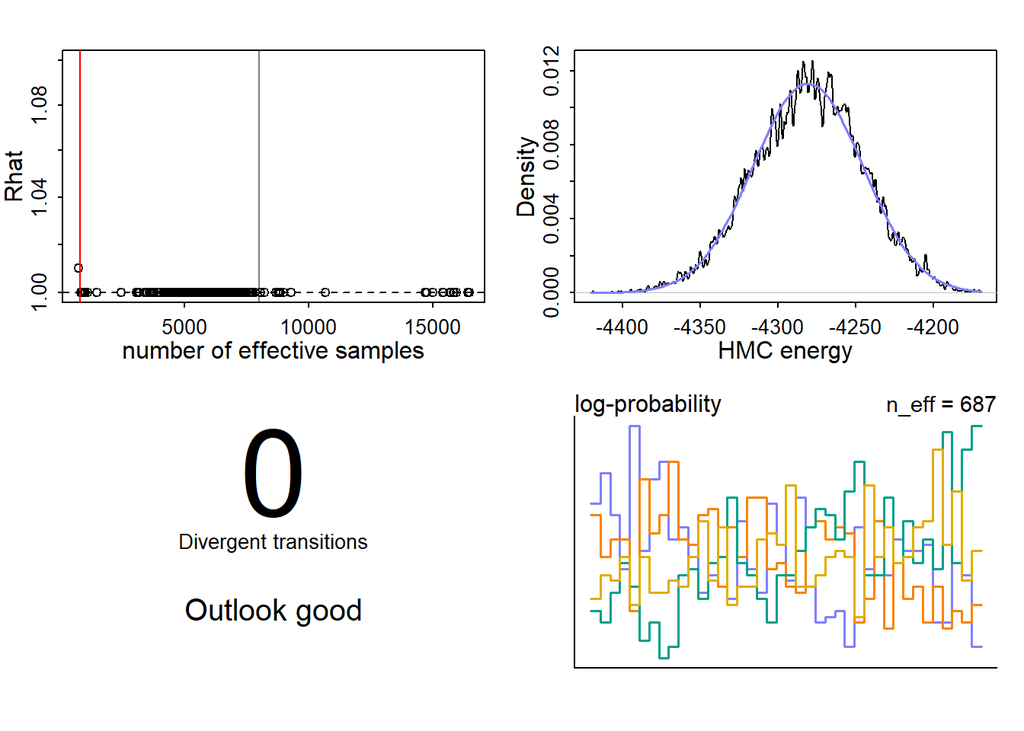

```r
dashboard(m1)
```

- without divergent but it has a few problem with efficiency, as I can see (might be different on what you see due to randomized data).
- I will try to eliminate by removing parameters.

```r
m1.2<- ulam(
    alist (
    # Main model K
        K ~ normal(mu_K, U),
        logit(mu_K) <- aK + bK_S * S + bK_SL * SL[i] + bK_dK * dK + bK_T[T],

        c(aK, bK_S,  bK_SL, bK_Y, bK_dK) ~ normal(0,0.1),
        vector[25]: bK_T <- bK_T_bar + sigma_bK_T * z_bK_T[T],
        bK_T_bar ~ normal(0, 0.1),
        sigma_bK_T ~ exponential(1),
        z_bK_T[T] ~ normal(0, 0.1),

        U ~ exponential(1),

    # Model S
        S ~ normal(mu_S, sigma_S),
        logit(mu_S) <- aS + bS_dS * dS + bS_Y * Y[i] + bS_T[T],

        c(aS, bS_Y, bS_dS) ~ normal(0,0.1),
        vector[25]: bS_T <- bS_T_bar + sigma_bS_T * z_bS_T[T],
        bS_T_bar ~ normal(0, 0.1),
        sigma_bS_T ~ exponential(1),
        z_bS_T[T] ~ normal(0, 0.1),

        sigma_S ~ exponential(1),

    # Model SL by Y
        vector[200]: SL ~ normal(inv_logit(6 * Y - 2) - 0.04, 0.05),

    # Model T
        T ~ poisson(Y * 25),

    # Model T by Y
        vector[200]:Y ~ normal( 0.5, 0.2)
    ), dat = d, constraints = list(
        SL   = "lower=0,upper=1",
        Y    = "lower=0,upper=1"
    ), chains=4, cores=4, iter= 4000, warmup = 2000, log_lik=TRUE, max_treedepth = 13, control = list(
    adapt_delta = 0.99
  )
)
```

```
## Running MCMC with 4 parallel chains, with 1 thread(s) per chain...
##
## Chain 1 Iteration:    1 / 4000 [  0%]  (Warmup)
```

```
## Chain 2 Iteration:    1 / 4000 [  0%]  (Warmup)
```

```
## Chain 3 Iteration:    1 / 4000 [  0%]  (Warmup)
```

```
## Chain 4 Iteration:    1 / 4000 [  0%]  (Warmup)
```

[output not shown]

[output cut: 117 more lines]

```
## Chain 2 Iteration: 3600 / 4000 [ 90%]  (Sampling)
## Chain 3 Iteration: 4000 / 4000 [100%]  (Sampling)
## Chain 3 finished in 167.8 seconds.
## Chain 1 Iteration: 3900 / 4000 [ 97%]  (Sampling)
## Chain 1 Iteration: 4000 / 4000 [100%]  (Sampling)
## Chain 1 finished in 171.2 seconds.
## Chain 2 Iteration: 3700 / 4000 [ 92%]  (Sampling)
## Chain 2 Iteration: 3800 / 4000 [ 95%]  (Sampling)
## Chain 2 Iteration: 3900 / 4000 [ 97%]  (Sampling)
## Chain 2 Iteration: 4000 / 4000 [100%]  (Sampling)
## Chain 2 finished in 182.3 seconds.
##
## All 4 chains finished successfully.
## Mean chain execution time: 165.6 seconds.
## Total execution time: 182.4 seconds.
```

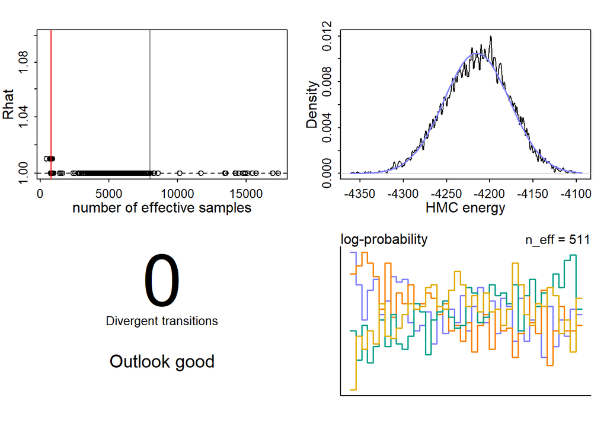

```r
dashboard(m1.2)
```

- This is still not the best model with low efficiency. I will remove one more parameter.
- I can remove bK_T or bS_T but this time, I want to keep the information as other models keep it by stratification.

```r
m1.3<- ulam(
    alist (
    # Main model K
        K ~ normal(mu_K, U),
        logit(mu_K) <- aK + bK_S * S + bK_SL * SL[i] + bK_dK * dK + bK_T[T],

        c(aK, bK_S,  bK_SL, bK_dK) ~ normal(0,0.1),
        vector[25]: bK_T <- bK_T_bar + sigma_bK_T * z_bK_T[T],
        bK_T_bar ~ normal(0, 0.1),
        sigma_bK_T ~ exponential(1),
        z_bK_T[T] ~ normal(0, 0.1),

        U ~ exponential(1),

    # Model S
        S ~ normal(mu_S, sigma_S),
        logit(mu_S) <- aS + bS_dS * dS + bS_T[T],

        c(aS, bS_dS) ~ normal(0,0.1),
        vector[25]: bS_T <- bS_T_bar + sigma_bS_T * z_bS_T[T],
        bS_T_bar ~ normal(0, 0.1),
        sigma_bS_T ~ exponential(1),
        z_bS_T[T] ~ normal(0, 0.1),

        sigma_S ~ exponential(1),

    # Model SL by Y
        vector[200]: SL ~ normal(inv_logit(6 * Y - 2) - 0.04, 0.05),

    # Model T
        T ~ poisson(Y * 25),

    # Model T by Y
        vector[200]:Y ~ normal( 0.5, 0.2)
    ), dat = d, constraints = list(
        SL   = "lower=0,upper=1",
        Y    = "lower=0,upper=1"
    ), chains=4, cores=4, iter= 4000, warmup = 2000, log_lik=TRUE, max_treedepth = 13, control = list(
    adapt_delta = 0.99
  )
)
```

```
## Running MCMC with 4 parallel chains, with 1 thread(s) per chain...
##
## Chain 1 Iteration:    1 / 4000 [  0%]  (Warmup)
```

```
## Chain 2 Iteration:    1 / 4000 [  0%]  (Warmup)
```

```
## Chain 3 Iteration:    1 / 4000 [  0%]  (Warmup)
```

```
## Chain 4 Iteration:    1 / 4000 [  0%]  (Warmup)
```

[output not shown]

[output cut: 117 more lines]

```
## Chain 4 Iteration: 3100 / 4000 [ 77%]  (Sampling)
## Chain 4 Iteration: 3200 / 4000 [ 80%]  (Sampling)
## Chain 4 Iteration: 3300 / 4000 [ 82%]  (Sampling)
## Chain 4 Iteration: 3400 / 4000 [ 85%]  (Sampling)
## Chain 4 Iteration: 3500 / 4000 [ 87%]  (Sampling)
## Chain 4 Iteration: 3600 / 4000 [ 90%]  (Sampling)
## Chain 4 Iteration: 3700 / 4000 [ 92%]  (Sampling)
## Chain 4 Iteration: 3800 / 4000 [ 95%]  (Sampling)
## Chain 4 Iteration: 3900 / 4000 [ 97%]  (Sampling)
## Chain 4 Iteration: 4000 / 4000 [100%]  (Sampling)
## Chain 4 finished in 120.7 seconds.
##
## All 4 chains finished successfully.
## Mean chain execution time: 96.5 seconds.
## Total execution time: 120.9 seconds.
```

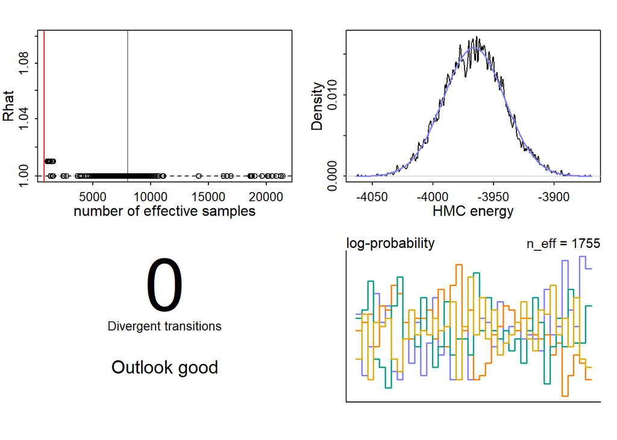

```r
dashboard(m1.3)
```

```r
precis(m1.3, depth = 1)
```

```
##                   mean          sd        5.5%       94.5%     rhat  ess_bulk
## bK_dK      -0.19856447 0.015133285 -0.22260120 -0.17391824 1.000739 11028.229
## bK_SL       0.62927086 0.089103688  0.48356732  0.76755175 1.001717  2740.762
## bK_S        0.27031143 0.100968015  0.10603295  0.43082214 1.000313  9306.753
## aK         -0.24458044 0.115915330 -0.43026910 -0.06468161 1.000778  3888.969
## bK_T_bar   -0.24415926 0.116502592 -0.43364681 -0.05991542 1.000793  3969.331
## sigma_bK_T  9.23436727 1.945372995  6.23892242 12.39720899 1.003683  1497.011
## U           0.03667259 0.003303398  0.03161322  0.04206216 1.001329  2475.333
## bS_dS      -0.20963065 0.015923328 -0.23507845 -0.18450047 1.000933 16938.655
## aS         -0.33563059 0.076248204 -0.45747743 -0.21377968 1.000715  8045.840
## bS_T_bar   -0.33743531 0.076322753 -0.45986031 -0.21400896 1.000265  7925.595
## sigma_bS_T  1.93444756 0.478641550  1.29823193  2.78999930 1.001704  2451.008
## sigma_S     0.04626542 0.002443699  0.04245785  0.05024831 1.001218 14176.088
```

```r
post <- extract.samples(m1.3)
```

#### Hidden parameters

- The hidden parameters are estimated by the model constraints and distributions.
- It is expected that the difference is small and has similar trend as the original data.

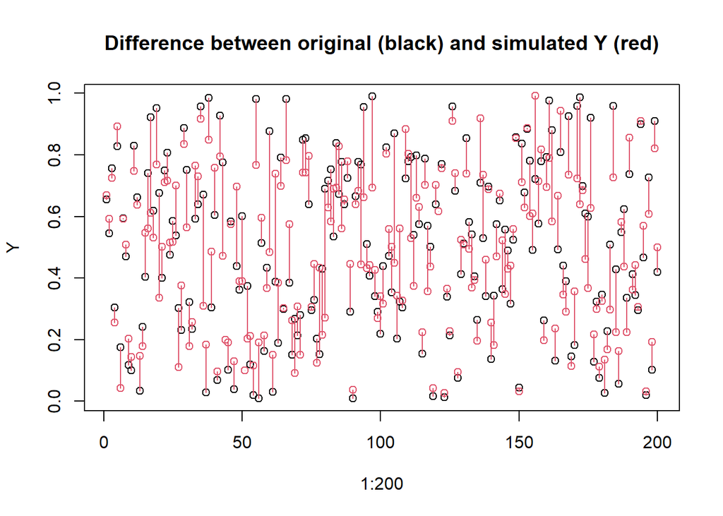

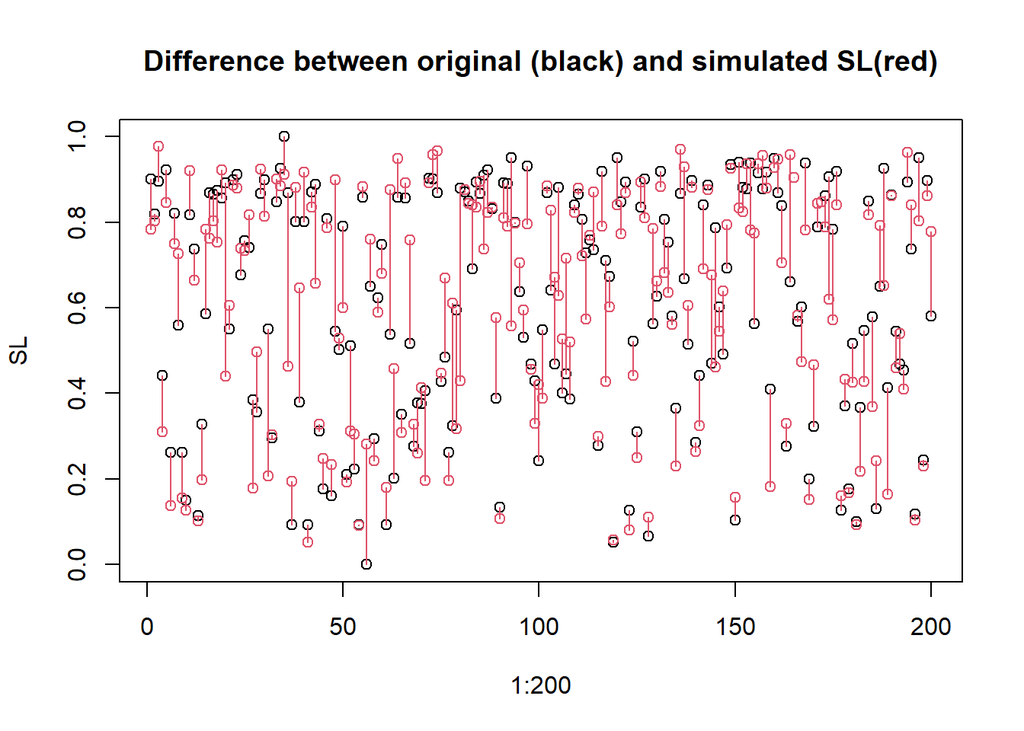

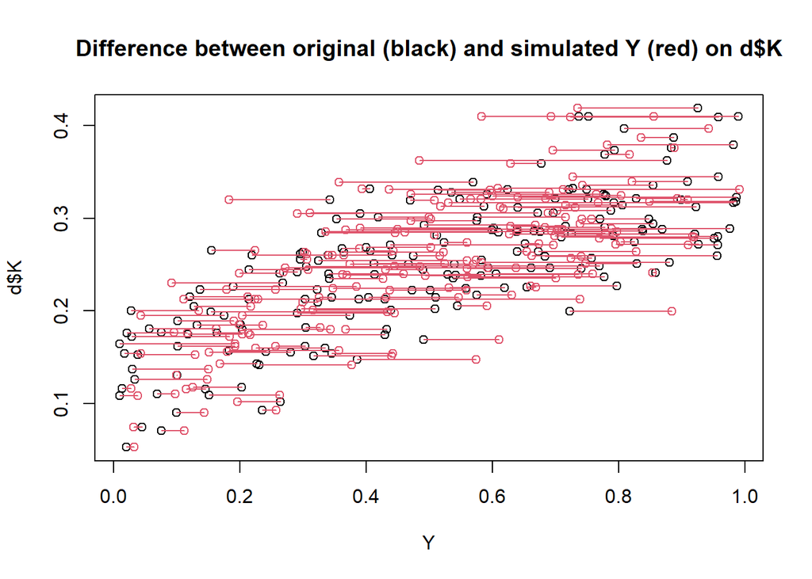

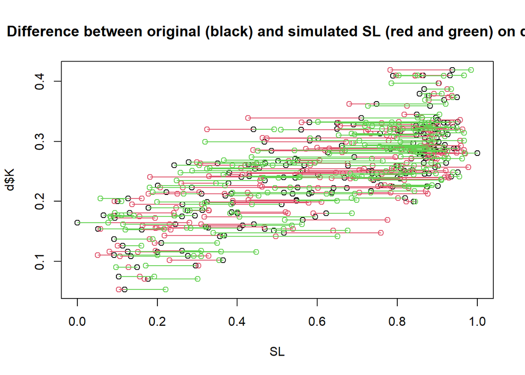

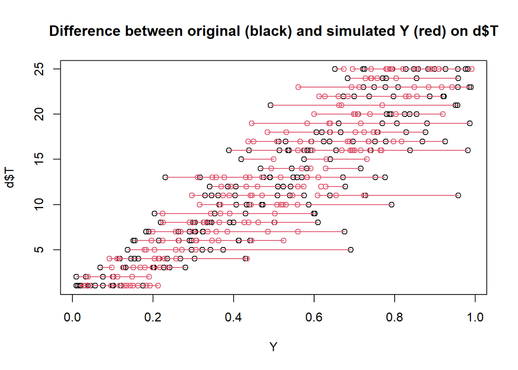

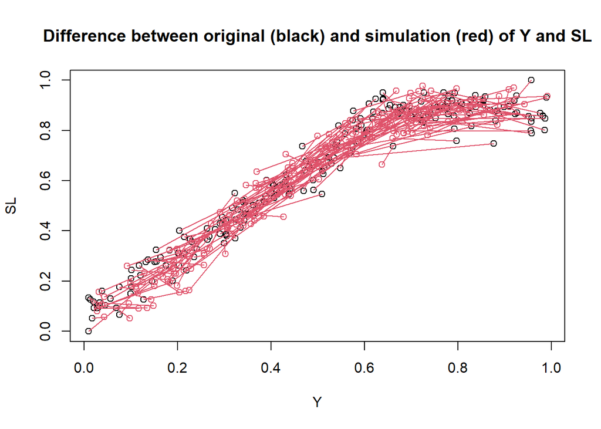

```r
# Posterior Y changes
plot(1:200, Y, main = "Difference between original (black) and simulated Y (red)")
points(1:200, post$Y[1,], col = 2)
for(i in 1 : 200) lines(c(i, i), c(post$Y[1,i], Y[i]), col = 2)

plot(1:200, SL, main = "Difference between original (black) and simulated SL(red)")
points(1:200, post$SL[1,], col = 2)
for(i in 1 : 200) lines(c(i, i), c(post$SL[1,i], SL[i]), col = 2)

# check Y and SL with K
plot(Y, d$K, main = "Difference between original (black) and simulated Y (red) on d$K")
points(post$Y[1,], d$K, col = 2)
for(i in 1 : 200) lines(c(post$Y[1,i], Y[i]), c(d$K[i], d$K[i]), col = 2)

plot(SL, d$K, main = "Difference between original (black) and simulated SL (red and green) on d$K")
points(post$SL[1,], d$K, col = 2)
for(i in 1 : 200) lines(c(post$SL[1,i], SL[i]), c(d$K[i], d$K[i]), col = 2)
points(post$SL[2,], d$K, col = 3)
for(i in 1 : 200) lines(c(post$SL[2,i], SL[i]), c(d$K[i], d$K[i]), col = 3)

# Y and T
plot(Y, d$T, main = "Difference between original (black) and simulated Y (red) on d$T")
points(post$Y[1,], d$T ,col = 2)
for (i in 1:200) lines(c(Y[i], post$Y[1,i]), c(d$T[i],d$T[i]), col = 2)

# Y and SL both hidden parameters
plot(Y, SL, main = "Difference between original (black) and simulation (red) of Y and SL")
points(post$Y[1,], post$SL[1,], col=2)
for(i in 1 : 200) lines(c(Y[i], post$Y[1,i]), c(SL[i], post$SL[1,i]), col = 2)
```

=> this shows that the difference is not very large and hidden parameters have similar trend as the original (synthetized) data.